# Dealing with Heterogeneity

```r
# Do we need the Treatment:Nutrient 2-way interaction?
## Yes, adding it makes the model fit better the data

# Reduced the generalized linear regression model above by removing Biomass
# this is the least significant term .
gls.ieno.ML5b <- update(gls.ieno.ML4, ". ~ . -Biomass")
anova(gls.ieno.ML5b)
```

```
## Denom. DF: 102
##                    numDF   F-value p-value
## (Intercept)            1 177.91543  <.0001
## Treatment              1  13.88491  0.0003
## Nutrient               2   3.20236  0.0448
## Treatment:Nutrient     2 117.03745  <.0001
```

```r
# contrast full and reduced model
anova(
  gls.ieno.ML4, # full model
  gls.ieno.ML5b # reduced model
)
```

```
##               Model df      AIC      BIC    logLik   Test  L.Ratio p-value
## gls.ieno.ML4      1 13 321.7872 356.6549 -147.8936
## gls.ieno.ML5b     2 12 321.2595 353.4450 -148.6297 1 vs 2 1.472279   0.225
```

```r
# Do we need the Biomass?
## The ANOVA function indicates that the Biomass can be dropped (the two models are not significantly different, so no need to overcomplicate). Also, the reduced model has a lower AIC.
## at this point, all predictors are significant, and we could stop here!

# Reduced the generalized linear regression model above by removing the Treatment:Nutrient 2-way interaction
# this is the last 2-way interaction.
gls.ieno.ML6 <- update(gls.ieno.ML5b, ". ~ . - Treatment:Nutrient")
anova(gls.ieno.ML6)
```

```
## Denom. DF: 104
##             numDF   F-value p-value
## (Intercept)     1 107.03520  <.0001
## Treatment       1  44.36011  <.0001
## Nutrient        2  20.55151  <.0001
```

```r
# contrast full and reduced model
anova(
  gls.ieno.ML5b, # full model
  gls.ieno.ML6 # reduced model
)
```

```
##               Model df      AIC      BIC    logLik   Test  L.Ratio p-value
## gls.ieno.ML5b     1 12 321.2595 353.4450 -148.6297
## gls.ieno.ML6      2 10 406.0323 432.8536 -193.0161 1 vs 2 88.77283  <.0001
```

```r
# Do we need the Treatment:Nutrient? interaction?
## Yes, adding it makes the model fit better the data
```

The process above of repeated comparison of nested models resulted in selecting the best fixed-effect structure. That is a model containing `Nutrient`, `Treatment` enrichment, and their interaction (`Treatment:Nutrient).

**Your task:**

Now you will reapply the best model but use a REML estimation.

With the model implementation above, you will now assess for: residuals’ Normality, independence of observations, and homogeneity of variances.

Can Normality, independence, and homogeneity be safely assumed?

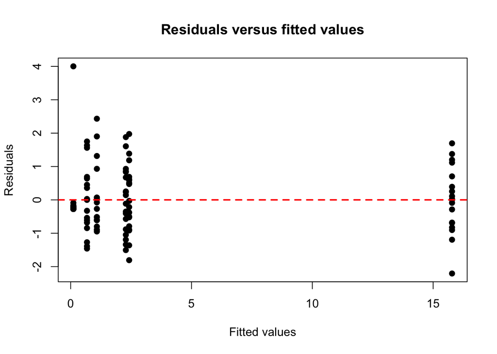

```r
# Build your final model
gls.ieno.Final <- gls(Concentration ~ Treatment * Nutrient, # Best fixed effect combination
  weights = varIdent(form = ~ 1 | Treatment * Nutrient), # the selected variance structure
  method = "REML", # the inference method
  data = ieno
) # the source dataset

# Assess Homogeneity of variances
# extract the residuals
E <- resid(gls.ieno.Final, # the gls model
  type = "pearson"
) # the residual type

# extract the fitted values
Fit <- fitted(gls.ieno.Final)

# Plot Homogeneity of variances
plot(
  x = Fit, # fitted values
  y = E, # Normalized Residuals
  pch = 19, # make the points filled points
  xlab = "Fitted values", ylab = "Residuals", # x and Y axes labels
  main = "Residuals versus fitted values"
) # main figure legend
# add a horizontal line
abline(
  h = 0, # set a horizontal line at zero
  col = "red", # make the line red
  lwd = 2, # set the line width
  lty = 2 # set the line type
)
```

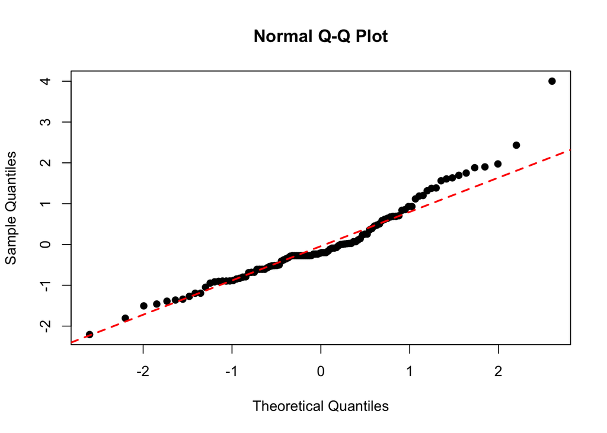

```r
# Assess normality of the residuals
# make a qqplot of the residuals (use qqnorm)
qqnorm(
  y = E, # the Normalized Residuals object
  pch = 19
) # make the dots filled circles
# Add the trend line
qqline(E, # the Normalized Residuals object
  col = "red", # make the line red
  lwd = 2, # set the line width
  lty = 2 # set the line type
)
```

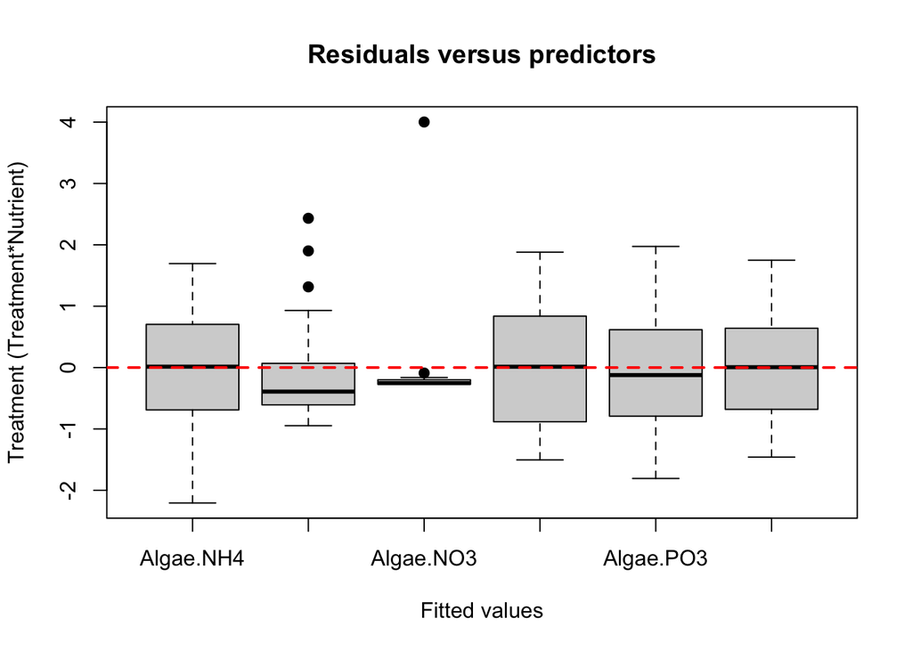

```r
# Assess independence of the observations
# boxplot of residuals vs predictors
boxplot(E ~ ieno$Treatment * ieno$Nutrient, # Normalized Residuals vs. Treatment
  pch = 19, # make the points filled points
  xlab = "Fitted values", ylab = "Treatment (Treatment*Nutrient)", # x and Y axes labels
  main = "Residuals versus predictors"
) # main figure legend
# add a horizontal line
abline(
  h = 0, # set a horizontal line at zero
  col = "red", # make the line red
  lwd = 2, # set the line width
  lty = 2 # set the line type
)
```

```r
# Can you safely assume Normality, independence, and homogeneity?
## Yes, the residuals are close to normally distributed. There is no trend in the residuals compared to the predictors or the fitted values.
```

Assuming that everything is OK, we can now proceed to the last step and present the relevant output of the final model.

**Your task:**

Using the `summary()` function, answer the following questions:

- Which factor or combination of these has the largest effect?
- Which factor or combination of these has the largest variance?
- Are all predictors significantly different from zero as a 5% level?
- Why is the interaction term significant?

```r
# Use the `summary()` function to get an overview of the effects
summary(gls.ieno.Final)
```

```
## Generalized least squares fit by REML
##   Model: Concentration ~ Treatment * Nutrient
##   Data: ieno
##        AIC      BIC    logLik
##   327.9174 359.4171 -151.9587
##
## Variance function:
##  Structure: Different standard deviations per stratum
##  Formula: ~1 | Treatment * Nutrient
##  Parameter estimates:
## NoAlgae*NO3   Algae*NO3 NoAlgae*NH4   Algae*NH4 NoAlgae*PO3   Algae*PO3
##   1.0000000   0.5010466   1.3323362   8.4363584   0.4860658   1.1073351
##
## Coefficients:
##                                  Value Std.Error   t-value p-value
## (Intercept)                   15.78139  1.629670  9.683792       0
## TreatmentNoAlgae             -14.69763  1.649868 -8.908365       0
## NutrientNO3                  -15.66972  1.632542 -9.598358       0
## NutrientPO3                  -13.36137  1.643649 -8.129088       0
## TreatmentNoAlgae:NutrientNO3  16.86929  1.663956 10.138067       0
## TreatmentNoAlgae:NutrientPO3  12.95293  1.666324  7.773353       0
##
##  Correlation:
##                              (Intr) TrtmNA NtrNO3 NtrPO3 TNA:NN
## TreatmentNoAlgae             -0.988
## NutrientNO3                  -0.998  0.986
## NutrientPO3                  -0.991  0.979  0.990
## TreatmentNoAlgae:NutrientNO3  0.979 -0.992 -0.981 -0.971
## TreatmentNoAlgae:NutrientPO3  0.978 -0.990 -0.976 -0.986  0.982
##
## Standardized residuals:
##        Min         Q1        Med         Q3        Max
## -2.2062707 -0.6078788 -0.2069959  0.5250832  4.0019026
##
## Residual standard error: 0.8195605
## Degrees of freedom: 108 total; 102 residual
```

```r
# Which combination of has the largest effect?
sort(abs(coef(gls.ieno.Final)[-1]),
  decreasing = T
)
```

```
## TreatmentNoAlgae:NutrientNO3                  NutrientNO3
##                     16.86929                     15.66972
##             TreatmentNoAlgae                  NutrientPO3
##                     14.69763                     13.36137
## TreatmentNoAlgae:NutrientPO3
##                     12.95293
```

```r
## TreatmentNoAlgae:NutrientNO3

# Which combination of predictors has the largest variance (see the Variance function output)?
## Algae*NH4

# Are all predictors significantly different form zero as a 5% level?
coef(summary(gls.ieno.Final))
```

```
##                                  Value Std.Error   t-value      p-value
## (Intercept)                   15.78139  1.629670  9.683792 4.082012e-16
## TreatmentNoAlgae             -14.69763  1.649868 -8.908365 2.108392e-14
## NutrientNO3                  -15.66972  1.632542 -9.598358 6.309173e-16
## NutrientPO3                  -13.36137  1.643649 -8.129088 1.071727e-12
## TreatmentNoAlgae:NutrientNO3  16.86929  1.663956 10.138067 4.028220e-17
## TreatmentNoAlgae:NutrientPO3  12.95293  1.666324  7.773353 6.306883e-12
```

```r
## YEs!!

# Why is the interaction term significant?
## Because the observations exposed to algae treatment and NH4 enrichment have the highest values.
```

## Final Points

Here you have focused on developing a model that addresses one of the main problems in linear regressions: Heterogeneity in the variance. For this, you used a generalised least squares (GLS) modelling framework, which is essentially a weighted linear regression. This framework allows using the predictors at hand to model the residual variability.

It would help if you remembered that the best way to select the best variance structure and fixed-effects is based on model comparisons. However, choosing the best variance structure is based on GLS models fitted using restricted maximum likelihood. In contrast, fixed effects selection uses models that are fitted using maximum likelihood.

One last point, these are linear regressions!. Therefore, after all your efforts addressing the heterogeneity of variances are done, you still need to check if it fulfils the linear regression assumptions. That means checking for homogeneity of variances, Normality of residuals, independence of observations, linearity in the relations, and no collinearity amongst predictors.